# ISYE 6402 Midterm 2

# Background

For this midterm exam, you will analyze vehicular collision data for the New York City borough of Manhattan. The data records the number of collisions involving motor vehicles in Manhattan each week from the beginning of 2013 to the end of 2021. Columns yr and wk designate the year and week number during which each data point was recorded, respectively, while the collisions column records the number of collisions during that week.

```r
library(zoo)
library(lubridate)
library(mgcv)
library(TSA)
library(dynlm)
library(rugarch)
library(tseries)
library(fGarch)
```

# Instructions on reading the data

To read the data in `R`, save the file in your working directory (make sure you have changed the directory if different from the R working directory) and read the data using the `R` function `read.csv()`

```r
#Read in data, split into full and abridged data
colls<-read.csv("Midterm 2 Data.csv")
```

# Training & Testing Data

For this data analysis, you will divide the data as follows.

**Pre-pandemic analysis:** The training data will consists of years 2013-2018 and the year 2019 excluding the last 8 weeks of the year. The last 8 weeks of 2019 will will then be the testing data. The predictions in this analysis will be 4-week rolling predictions; that is first obtain the predictions of the first four weeks out of the eight weeks of training data, then the training data are updated to include these four weeks so that the last four weeks of 2019 to be predicted.

**Pandemic analysis:** The training data will consists of years 2013-2020 and the year 2021 excluding the last 8 weeks of this year. The last 8 weeks of 2021 will then be the testing data. The predictions in this analysis will be 4-week rolling predictions; that is first obtain the predictions of the first four weeks out of the eight weeks of training data, then the training data are updated to include these four weeks so that the last four weeks of 2021 to be predicted. This analysis will be done with and without the 2020 pandemic year.

# Part 1: Exploratory Data Analysis of the Entire Time Series

**1a.** Plot the Time Series and the ACF plots for the entire data. Comment on the stationarity of the data, as well as any features of note.

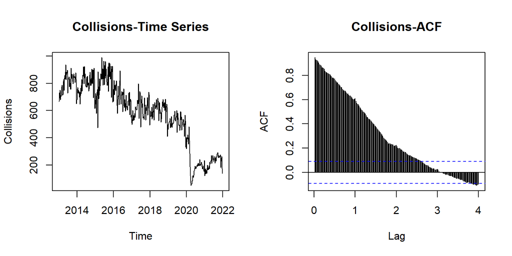

```r
colls.ts<-ts(colls$collisions,start=2013,freq=52)
par(mfrow=c(1,2))
plot(colls.ts,ylab="Collisions",main="Collisions-Time Series")
acf(colls.ts,lag.max=52*4,main="Collisions-ACF")
```

*Response: Question 1a*

The time series plot of the data clearly exhibits a non-constant mean, as well as fluctuations in variance, which decreases notably from the beginning of the COVID-19 pandemic onward. The ACF plot confirms the presence of a trend in the data. The data is not stationary.

**1b.** Plot the Time Series and the ACF plots for the differenced data. Compare these plots with the plots that you produced in question 1(a) in terms of the assumptions of stationarity.

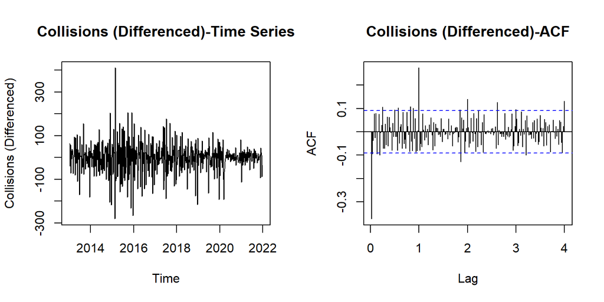

```r
colls.diff.ts<-diff(colls.ts)
par(mfrow=c(1,2))
plot(colls.diff.ts,ylab="Collisions (Differenced)",main="Collisions (Differenced)-Time Series")
acf(colls.diff.ts,lag.max=52*4,main="Collisions (Differenced)-ACF")
```

*Response: Question 1b*

Differencing the data has removed the trend, but has made the non-constant nature of the variance in the data even more apparent. The ACF plot of the differenced data seems to indicate the presence of possible seasonality in the data, with significant spikes at the scaled lags. Because of the clear presence of heteroskedasticity and the possible presence of seasonality in the differenced data, we cannot conclude that the differenced data is stationary.

**1c.** Comment on the appropriateness of using both ARIMA and ARMA-GARCH methods to model the data based on the data features that you observed in 1(a) and 1(b). What other data features (if any) should be considered when selecting an appropriate method for modeling the collision data?

*Response: Question 1c*

ARIMA modeling would likely be a poor option to use to model the data due to the heteroskedasticity in the data. ARMA-GARCH modeling would likely prove a better method for modeling the data. Given our observations in 1(b), it could also prove helpful to choose a method to model the data which includes a seasonal component.

# Part 2: Model Fitting: Pre-pandemic Data Analysis

**2a.** Fit a seasonality model on the training data using the ANOVA approach. Derive the residuals of the seasonality model. Use the iterative approach to choose the optimal orders for an ARIMA model fit to the residual training data, using max (p,d,q) of (4,1,4) and selecting with the AIC score. Fit the model with the selected ARIMA order to the residual training data and call this model **model1**. Indicate the orders you selected and comment on the statistical significance of the model coefficients.

```r
pre<-colls[colls$yr < 2020,]
pre.ts<-ts(pre$collisions,start=2013,freq=52)
l<-length(pre.ts)
pre.seas<-lm(pre.ts~season(pre.ts))
pre.resids<-ts(pre.seas$residuals)
pre.resids.train<-pre.resids[1:(l-8)]
pre.resids.test<-pre.resids[(l-7):l]
#Fit ARIMA model to residuals of seasonal model
test_modelA <- function(p,d,q){
  mod = arima(pre.resids.train, order=c(p,d,q),method="ML")
  current.aic = AIC(mod)
  df = data.frame(p,d,q,current.aic)
  names(df) <- c("p","d","q","AIC")
  #print(paste(p,d,q,current.aic,sep=" "))
  return(df)
}

orders = data.frame(Inf,Inf,Inf,Inf)
names(orders) <- c("p","d","q","AIC")

for (p in 0:4){
  for (d in 0:1){
    for (q in 0:4) {
      possibleError <- tryCatch(
        orders<-rbind(orders,test_modelA(p,d,q)),
        error=function(e) e
      )
      if(inherits(possibleError, "error")) next

    }
  }
}
orders <- orders[order(-orders$AIC),]
tail(orders,5)
```

```
##    p d q      AIC
## 10 0 1 3 3765.690
## 28 2 1 1 3765.334
## 51 4 1 4 3764.605
## 40 3 1 3 3764.189
## 31 2 1 4 3762.134
```

```r
model1<-arima(pre.resids.train, order=c(2,1,4),method="ML")
model1
```

```
##
## Call:
## arima(x = pre.resids.train, order = c(2, 1, 4), method = "ML")
##
## Coefficients:
##           ar1      ar2     ma1      ma2      ma3     ma4
##       -1.6367  -0.9022  0.7566  -0.4628  -0.6172  0.2027
## s.e.   0.0293   0.0281  0.0614   0.0596   0.0632  0.0597
##
## sigma^2 estimated as 2218:  log likelihood = -1874.07,  aic = 3760.13
```

```r
cat("\nModel1 p-values:\n")
```

```
##
## Model1 p-values:
```

```r
model1.coefs <-as.numeric(model1$coef)/as.numeric(sqrt(diag(model1$var.coef)))
model1.pvals <- 2 * (1 - pnorm(abs(model1.coefs)))
model1.pvals
```

```
## [1] 0.000000e+00 0.000000e+00 0.000000e+00 8.437695e-15 0.000000e+00
## [6] 6.787945e-04
```

*Response: Question 2a*

Orders (2,1,4) have the lowest AIC value. All the coefficients of the ARIMA (2,1,4) model fit to the residual training data are statistically significant.

**2b.** Fit an ARMA-GARCH model to the residual training data from Question 2a using max orders (5,5)x(2,2). Use the p and q values that you selected when creating the ARIMA model above as the initial ARMA orders. Fit the model with the selected ARMA-GARCH orders to the residual training data and call this model **model2**. Compare the orders that you selected for model1 and model2. Interpret the difference.

```r
test_modelAGG <- function(m,n){
  spec = ugarchspec(variance.model=list(garchOrder=c(m,n)),
                    mean.model=list(armaOrder=c(2,4),
                                    include.mean=T),
                    distribution.model="std")
  fit = ugarchfit(spec, pre.resids.train, solver = 'hybrid')
  current.bic = infocriteria(fit)[2]
  df = data.frame(m,n,current.bic)
  names(df) <- c("m","n","BIC")
  #print(paste(m,n,current.bic,sep=" "))
  return(df)
}

ordersAGG = data.frame(Inf,Inf,Inf)
names(ordersAGG) <- c("m","n","BIC")

for (m in 0:2){
  for (n in 0:2){
    possibleError <- tryCatch(
      ordersAGG<-rbind(ordersAGG,test_modelAGG(m,n)),
      error=function(e) e
    )
    if(inherits(possibleError, "error")) next
  }
}
ordersAGG <- ordersAGG[order(-ordersAGG$BIC),]
tail(ordersAGG,3)
```

```
##   m n      BIC
## 7 2 0 10.66938
## 6 1 2 10.66172
## 5 1 1 10.66087
```

```r
#ARMA update
#ARIMA-GARCH: Select ARMA order given GARCH=(1,1)
test_modelAGA <- function(p,q){
  spec = ugarchspec(variance.model=list(garchOrder=c(1,1)),
                    mean.model=list(armaOrder=c(p,q),
                                    include.mean=T),
                    distribution.model="std")
  fit = ugarchfit(spec, pre.resids.train, solver = 'hybrid')
  current.bic = infocriteria(fit)[2]
  df = data.frame(p,q,current.bic)
  names(df) <- c("p","q","BIC")
  #print(paste(p,q,current.bic,sep=" "))
  return(df)
}

ordersAGA = data.frame(Inf,Inf,Inf)
names(ordersAGA) <- c("p","q","BIC")
for (p in 0:5){
  for (q in 0:5){
    possibleError <- tryCatch(
      ordersAGA<-rbind(ordersAGA,test_modelAGA(p,q)),
      error=function(e) e
    )
    if(inherits(possibleError, "error")) next
  }
}
ordersAGA <- ordersAGA[order(-ordersAGA$BIC),]
tail(ordersAGA,3)
```

```
##    p q      BIC
## 30 4 4 10.62636
## 35 5 3 10.62580
## 23 3 3 10.62063
```

```r
test_modelAGG <- function(m,n){
  spec = ugarchspec(variance.model=list(garchOrder=c(m,n)),
                    mean.model=list(armaOrder=c(3,3),
                                    include.mean=T),
                    distribution.model="std")
  fit = ugarchfit(spec, pre.resids.train, solver = 'hybrid')
  current.bic = infocriteria(fit)[2]
  df = data.frame(m,n,current.bic)
  names(df) <- c("m","n","BIC")
  #print(paste(m,n,current.bic,sep=" "))
  return(df)
}

ordersAGG = data.frame(Inf,Inf,Inf)
names(ordersAGG) <- c("m","n","BIC")

for (m in 0:2){
  for (n in 0:2){
    possibleError <- tryCatch(
      ordersAGG<-rbind(ordersAGG,test_modelAGG(m,n)),
      error=function(e) e
    )
    if(inherits(possibleError, "error")) next
  }
}
ordersAGG <- ordersAGG[order(-ordersAGG$BIC),]
tail(ordersAGG,3)
```

```
##   m n      BIC
## 7 2 0 10.65211
## 4 1 0 10.64526
## 5 1 1 10.62063
```

```r
spec2 = ugarchspec(variance.model=list(garchOrder=c(1,1)),
                 mean.model=list(armaOrder=c(3, 3),
                 include.mean=T), distribution.model="std")
model2 = ugarchfit(spec2, pre.resids.train, solver = 'hybrid')
model2
```

```
##
## *---------------------------------*
## *          GARCH Model Fit        *
## *---------------------------------*
##
## Conditional Variance Dynamics
## -----------------------------------
## GARCH Model  : sGARCH(1,1)
## Mean Model   : ARFIMA(3,0,3)
## Distribution : std
##
## Optimal Parameters
## ------------------------------------
##          Estimate  Std. Error     t value Pr(>|t|)
## mu      56.312466    0.016823  3347.32427 0.000000
## ar1     -0.948480    0.000184 -5159.69511 0.000000
## ar2      0.958903    0.000162  5910.17334 0.000000
## ar3      1.003776    0.000188  5330.10409 0.000000
## ma1      1.230373    0.000288  4270.41491 0.000000
## ma2     -0.503266    0.000143 -3526.19905 0.000000
## ma3     -0.810577    0.000315 -2571.17762 0.000000
## omega  151.195991  449.754774     0.33617 0.736739
## alpha1   0.091284    0.112647     0.81036 0.417734
## beta1    0.842702    0.312309     2.69830 0.006970
## shape    6.892802    2.619539     2.63130 0.008506
##
## Robust Standard Errors:
##          Estimate  Std. Error     t value Pr(>|t|)
## mu      56.312466  1.7113e-01  329.058485  0.00000
## ar1     -0.948480  6.5060e-03 -145.778612  0.00000
## ar2      0.958903  1.0305e-02   93.055438  0.00000
## ar3      1.003776  8.8100e-03  113.941896  0.00000
## ma1      1.230373  4.4230e-03  278.151515  0.00000
## ma2     -0.503266  2.8200e-03 -178.480313  0.00000
## ma3     -0.810577  6.5350e-03 -124.045195  0.00000
## omega  151.195991  8.9154e+03    0.016959  0.98647
## alpha1   0.091284  2.2548e+00    0.040484  0.96771
## beta1    0.842702  6.2996e+00    0.133770  0.89358
## shape    6.892802  2.3769e+01    0.289991  0.77182
##
```

[output cut: 58 more lines]

```
## Negative Sign Bias  0.4848 0.6281
## Positive Sign Bias  0.5412 0.5887
## Joint Effect        0.6181 0.8923
##
##
## Adjusted Pearson Goodness-of-Fit Test:
## ------------------------------------
##   group statistic p-value(g-1)
## 1    20     9.169       0.9706
## 2    30    22.539       0.7972
## 3    40    33.888       0.7019
## 4    50    36.135       0.9140
##
##
## Elapsed time : 0.9978061
```

*Response: Question 2b*

The optimal orders for the ARMA-GARCH model fit to the residual training data are (3,3)x(1,1). Model2 contains one more AR coefficient and one less MA coefficient than model1 does. Like model1, all of the AR and MA coefficients for model2 are statistically significant.

**2c.** Fit a seasonal ARIMA (SARIMA) model on the training time series data (not the residuals from previous questions) using orders (0,1,2) with seasonal orders (1,0,1). Call this model **model3**. Also fit a GARCH model on the residuals of model3 using ARMA-GARCH orders (1,0)x(1,1), and call this model **model4**. Compare the statistical significance of the coefficients of model3 to those of model1. Likewise, compare the statistical significance of the coefficients of model4 to those of model2.

```r
pre.all.train<-pre.ts[1:(l-8)]
pre.all.test<-pre.ts[(l-7):l]
model3<-arima(pre.all.train,order=c(0,1,2),seasonal=list(orders=c(1,0,1),period=52),method="ML")
m3.resids<-resid(model3)
spec4 = ugarchspec(variance.model=list(garchOrder=c(1,1)),
                 mean.model=list(armaOrder=c(1, 0),
                 include.mean=T), distribution.model="std")
model4 = ugarchfit(spec4, m3.resids, solver = 'hybrid')
model3
```

```
##
## Call:
## arima(x = pre.all.train, order = c(0, 1, 2), seasonal = list(orders = c(1, 0,
##     1), period = 52), method = "ML")
##
## Coefficients:
##           ma1     ma2    sar1     sma1
##       -0.8669  0.0940  0.9984  -0.9508
## s.e.   0.0593  0.0606  0.0049   0.0760
##
## sigma^2 estimated as 2747:  log likelihood = -1950.48,  aic = 3908.95
```

```r
cat("\nModel3 p-values:\n")
```

```
##
## Model3 p-values:
```

```r
model3.coefs <-as.numeric(model3$coef)/as.numeric(sqrt(diag(model3$var.coef)))
model3.pvals <- 2 * (1 - pnorm(abs(model3.coefs)))
model3.pvals
```

```
## [1] 0.0000000 0.1209267 0.0000000 0.0000000
```

```r
model4
```

```
##
## *---------------------------------*
## *          GARCH Model Fit        *
## *---------------------------------*
##
## Conditional Variance Dynamics
## -----------------------------------
## GARCH Model  : sGARCH(1,1)
## Mean Model   : ARFIMA(1,0,0)
## Distribution : std
##
## Optimal Parameters
## ------------------------------------
##          Estimate  Std. Error  t value Pr(>|t|)
## mu      -0.971843    2.570775 -0.37804 0.705405
## ar1      0.021602    0.055243  0.39103 0.695772
## omega  149.470912  135.876773  1.10005 0.271311
## alpha1   0.079137    0.042141  1.87792 0.060392
## beta1    0.871189    0.075616 11.52119 0.000000
## shape    6.593850    2.581625  2.55415 0.010645
##
## Robust Standard Errors:
##          Estimate  Std. Error  t value Pr(>|t|)
## mu      -0.971843    2.502119 -0.38841 0.697714
## ar1      0.021602    0.059948  0.36034 0.718592
## omega  149.470912  111.159977  1.34465 0.178739
## alpha1   0.079137    0.043338  1.82604 0.067845
## beta1    0.871189    0.064356 13.53697 0.000000
## shape    6.593850    2.260419  2.91709 0.003533
##
## LogLikelihood : -1899.698
##
## Information Criteria
## ------------------------------------
##
## Akaike       10.706
## Bayes        10.771
## Shibata      10.706
## Hannan-Quinn 10.732
##
```

[output cut: 43 more lines]

```
## Negative Sign Bias  0.8483 0.3968
## Positive Sign Bias  0.3129 0.7545
## Joint Effect        0.8186 0.8450
##
##
## Adjusted Pearson Goodness-of-Fit Test:
## ------------------------------------
##   group statistic p-value(g-1)
## 1    20     21.64       0.3025
## 2    30     29.79       0.4247
## 3    40     43.78       0.2759
## 4    50     44.84       0.6423
##
##
## Elapsed time : 0.7042599
```

**2d.** Perform goodness-of-fit tests for each of the four models; specifically, evaluate the presence of serial correlation, heteroskedasticity, and normality in each model’s residuals, and interpret the test output, using $\alpha = .05$ as a significance threshold.

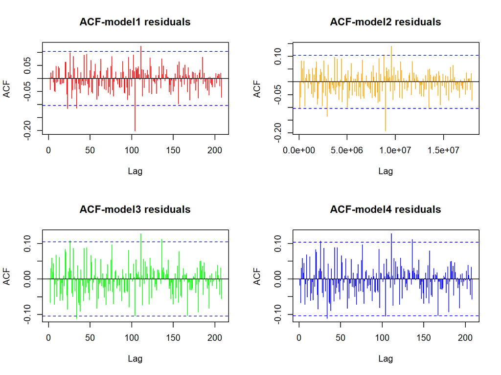

```r
res1<-residuals(model1)
res2<-residuals(model2)
res3<-residuals(model3)
res4<-residuals(model4)
par(mfrow=c(2,2))
acf(res1,lag.max=52*4,main="ACF-model1 residuals",col="red")
acf(res2,lag.max=52*4,main="ACF-model2 residuals",col="orange")
acf(res3,lag.max=52*4,main="ACF-model3 residuals",col="green")
acf(res4,lag.max=52*4,main="ACF-model4 residuals",col="blue")
```

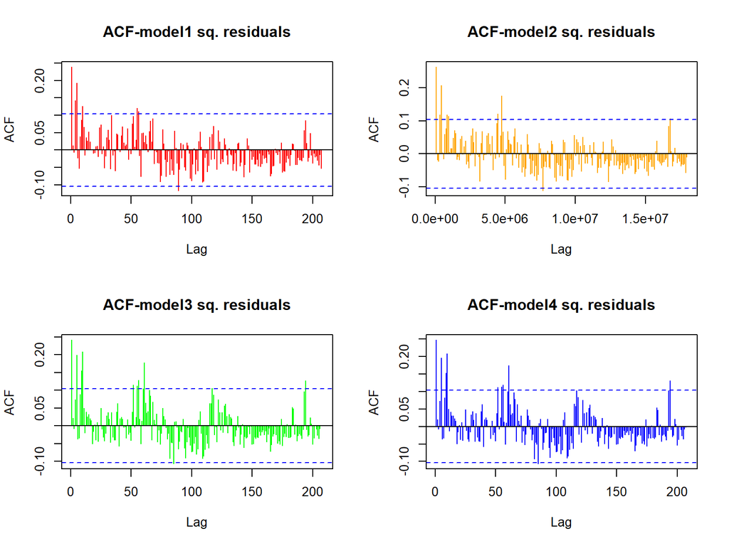

```r
par(mfrow=c(2,2))
acf(res1^2,lag.max=52*4,main="ACF-model1 sq. residuals",col="red")
acf(res2^2,lag.max=52*4,main="ACF-model2 sq. residuals",col="orange")
acf(res3^2,lag.max=52*4,main="ACF-model3 sq. residuals",col="green")
acf(res4^2,lag.max=52*4,main="ACF-model4 sq. residuals",col="blue")
```

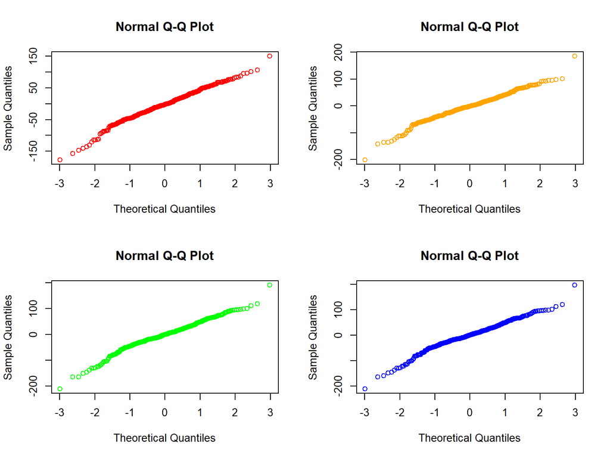

```r
par(mfrow=c(2,2))
qqnorm(res1,col="red")
qqnorm(res2,col="orange")
qqnorm(res3,col="green")
qqnorm(res4,col="blue")
```

```r
btpvalue<-function(data,pq){
  bt<-Box.test(data,lag=pq+1,type="Ljung",fitdf=pq)
  return(bt$p.value)
}

cat("Ljung-Box Test on Residuals:\n\tModel1:",btpvalue(res1,6),
    "\n\tModel2:",btpvalue(res2,8),
    "\n\tModel3:",btpvalue(res3,2),
    "\n\tModel4:",btpvalue(res4,3),
    "\nLjung-Box Test on Squared Residuals:\n\tModel1:",btpvalue(res1^2,6),
    "\n\tModel2:",btpvalue(res2^2,8),
    "\n\tModel3:",btpvalue(res3^2,2),
    "\n\tModel4:",btpvalue(res4^2,3))
```

```
## Ljung-Box Test on Residuals:
##  Model1: 0.149771
##  Model2: 0.0001166795
##  Model3: 0.1628493
##  Model4: 0.06736611
## Ljung-Box Test on Squared Residuals:
##  Model1: 6.673884e-11
##  Model2: 2.31215e-12
##  Model3: 3.951617e-06
##  Model4: 9.184127e-07
```

*Response: Question 2d*

At a significance threshold of $\alpha =.05$, we reject the null hypothesis of no serial correlation in the residuals for model2. The residuals for all four models appear to exhibit heteroskedasticity. All four models’ residuals appear to be relatively normally distributed, despite some departure from normality at the tails of each residual distribution.

# Part 3: Model Evaluation

**3a.** Apply the models identified in Part 2 and forecast collisions for the last eight weeks of year 2019 using a 4-lag rolling prediction approach; that is, predict four week at a time. Plot the forecasts for each model on the original time series and compare the forecasts to the actual values. (You do not need to plot the confidence intervals.) *Hint: Make sure you forecast taking into account all components of each of the models.*

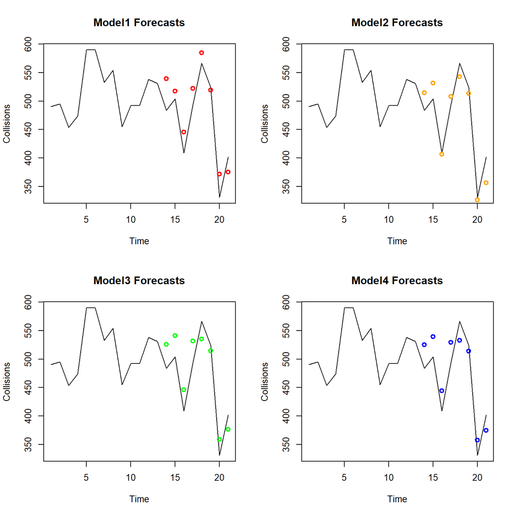

```r
#Predictions for first four weeks
#Forecasts for (S)ARIMA models
preds1<-predict(model1,n.ahead=4)
preds3<-predict(model3,n.ahead=4)


#Forecasts for variance models
fore.series.2<-NULL

for(f in 1:4){
  ## Fit models
  data = pre.resids.train
  if(f>=2)
    data = c(pre.resids.train,pre.resids.test[1:(f-1)])

  fmod = ugarchfit(spec2, data, solver = 'hybrid')

  ## Forecast
  fore2 = ugarchforecast(fmod, n.ahead=1)
  fore.series.2 = c(fore.series.2, fore2@forecast$seriesFor)

}


m3.resids.test<-pre.all.test[1:4]-preds3$pred

fore.series.4<-NULL

for(f in 1:4){
  ## Fit model
  data = m3.resids
  if(f>=2)
    data = c(m3.resids,m3.resids.test[1:(f-1)])

  fmod = ugarchfit(spec4, data, solver = 'hybrid')

  ## Forecast
  fore4 = ugarchforecast(fmod, n.ahead=1)
  fore.series.4 = c(fore.series.4, fore4@forecast$seriesFor)

}

l<-length(pre.seas$fitted.values)
preds1.orig<-preds1$pred+pre.seas$fitted.values[(l-7):(l-4)]
preds2.orig<-fore.series.2+pre.seas$fitted.values[(l-7):(l-4)]
preds3.orig<-preds3$pred
preds4.orig<-fore.series.4+preds3$pred

#Predictions for last four weeks
pre.resids.train.4wk<-c(pre.resids.train,pre.resids.test[1:4])
pre.resids.test.4wk<-pre.resids.test[5:8]
pre.all.train.4wk<-c(pre.all.train,pre.all.test[1:4])
model1.4wk<-arima(pre.resids.train, order=c(2,1,4),method="ML")
model2.4wk<-ugarchfit(spec2, pre.resids.train.4wk, solver = 'hybrid')
model3.4wk<-arima(pre.all.train.4wk,order=c(0,1,2),seasonal=list(orders=c(1,0,1),period=52),method="ML")
m3.resids.4wk<-resid(model3.4wk)
model4.4wk<-ugarchfit(spec4, m3.resids.4wk, solver = 'hybrid')

preds1.4wk<-predict(model1.4wk,n.ahead=4)
preds3.4wk<-predict(model3.4wk,n.ahead=4)

fore.series.2.4wk<-NULL

for(f in 1:4){
  ## Fit models
  data = pre.resids.train.4wk
  if(f>=2)
    data = c(pre.resids.train.4wk,pre.resids.test.4wk[1:(f-1)])

  fmod = ugarchfit(spec2, data, solver = 'hybrid')

  ## Forecast
  fore2 = ugarchforecast(fmod, n.ahead=1)
  fore.series.2.4wk = c(fore.series.2.4wk, fore2@forecast$seriesFor)

}


m3.resids.test.4wk<-pre.all.test[5:8]-preds3.4wk$pred

fore.series.4.4wk<-NULL

for(f in 1:4){
  ## Fit model
  data = m3.resids.4wk
  if(f>=2)
    data = c(m3.resids.4wk,m3.resids.test.4wk[1:(f-1)])

  fmod = ugarchfit(spec4, data, solver = 'hybrid')

  ## Forecast
  fore4 = ugarchforecast(fmod, n.ahead=1)
  fore.series.4.4wk = c(fore.series.4.4wk, fore4@forecast$seriesFor)

}
preds1.orig<-c(preds1.orig,preds1.4wk$pred+pre.seas$fitted.values[(l-3):l])
preds2.orig<-c(preds2.orig,fore.series.2.4wk+pre.seas$fitted.values[(l-3):l])
preds3.orig<-c(preds3.orig,preds3.4wk$pred)
preds4.orig<-c(preds4.orig,fore.series.4.4wk+preds3.4wk$pred)

#Plot predictions
par(mfrow=c(2,2))
ts.plot(pre.ts[(l-20):l],main="Model1 Forecasts",ylab="Collisions",
        ylim=c(min(pre.ts[(l-20):l]),max(pre.ts[(l-20):l])))
points(ts(preds1.orig,start=14),lwd=2,col="red")
ts.plot(pre.ts[(l-20):l],main="Model2 Forecasts",ylab="Collisions",
        ylim=c(min(pre.ts[(l-20):l]),max(pre.ts[(l-20):l])))
points(ts(preds2.orig,start=14),lwd=2,col="orange")
ts.plot(pre.ts[(l-20):l],main="Model3 Forecasts",ylab="Collisions",
        ylim=c(min(pre.ts[(l-20):l]),max(pre.ts[(l-20):l])))
points(ts(preds3.orig,start=14),lwd=2,col="green")
ts.plot(pre.ts[(l-20):l],main="Model4 Forecasts",ylab="Collisions",
        ylim=c(min(pre.ts[(l-20):l]),max(pre.ts[(l-20):l])))
points(ts(preds4.orig,start=14),lwd=2,col="blue")
```

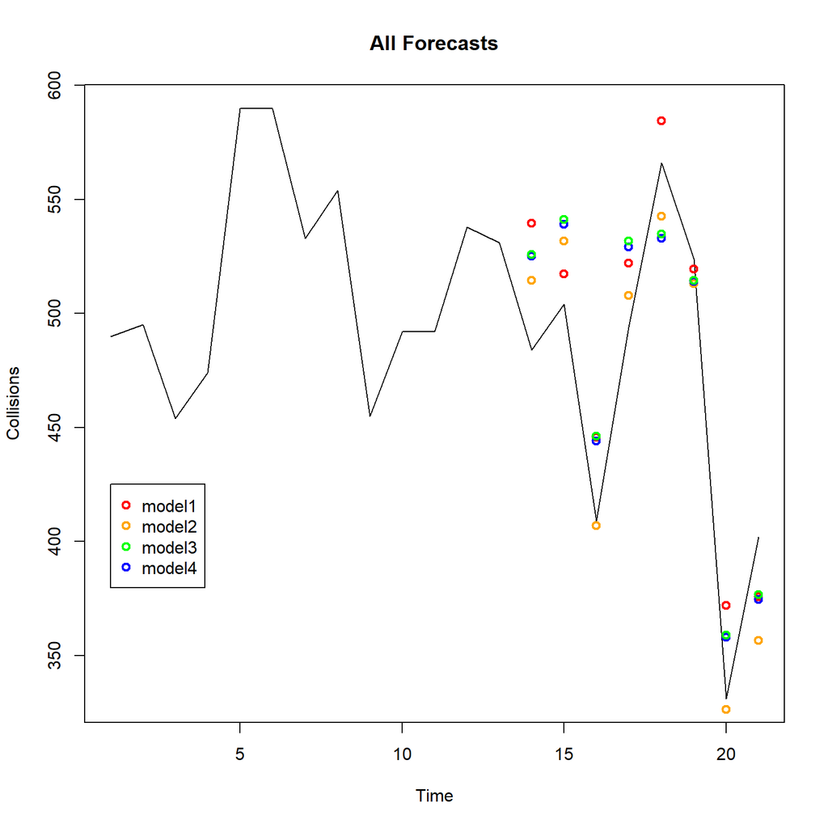

```r
par(mfrow=c(1,1))
ts.plot(pre.ts[(l-20):l],main="All Forecasts",ylab="Collisions",
        ylim=c(min(pre.ts[(l-20):l]),max(pre.ts[(l-20):l])))
points(ts(preds1.orig,start=14),lwd=2,col="red")
points(ts(preds2.orig,start=14),lwd=2,col="orange")
points(ts(preds4.orig,start=14),lwd=2,col="blue")
points(ts(preds3.orig,start=14),lwd=2,col="green")
legend(x=1,y=425,legend=c("model1","model2","model3","model4"),pch=1,
       pt.lwd = 2, col=c("red","orange","green","blue"))
```

*Response: Question 3a*

All four models appear to successfully capture the data’s seasonal pattern. The predicted values for all four models approximate the actual values very well, and none of the four models appear to significantly outperform the other models in terms of accuracy.

**3b.** Calculate MAPE and PM for the predictions of each of the four models. Compare the prediction accuracy of the four models based on these measures.

```r
cat("Model1 MAPE:",mean(abs(preds1.orig-pre.all.test)/pre.all.test),
   "\nModel1 PM:", sum((preds1.orig-pre.all.test)^2)/sum((pre.all.test-mean(pre.all.test))^2),
"\nModel2 MAPE:",mean(abs(preds2.orig-pre.all.test)/pre.all.test),
"\nModel2 PM:", sum((preds2.orig-pre.all.test)^2)/sum((pre.all.test-mean(pre.all.test))^2),
"\nModel3 MAPE:",mean(abs(preds3.orig-pre.all.test)/pre.all.test),
"\nModel3 PM:", sum((preds3.orig-pre.all.test)^2)/sum((pre.all.test-mean(pre.all.test))^2),
"\nModel4 MAPE:",mean(abs(preds4.orig-pre.all.test)/pre.all.test),
"\nModel4 PM:", sum((preds4.orig-pre.all.test)^2)/sum((pre.all.test-mean(pre.all.test))^2))
```

```
## Model1 MAPE: 0.06473436
## Model1 PM: 0.1955791
## Model2 MAPE: 0.04264017
## Model2 PM: 0.1122513
## Model3 MAPE: 0.06844672
## Model3 PM: 0.2028738
## Model4 MAPE: 0.06735597
## Model4 PM: 0.194775
```

*Response: Question 3b*

According to the MAPE and PM values calculated above, all four models have high prediction accuracy. Judging by these measures, model2 appears to slightly outperform the other three models in terms of prediction accuracy.

# Part 4: Reflection: Pre-pandemic vs Pandemic Analysis

**4.** Fit the same models you fitted on the training data for the Pre-pandemic Data Analysis in Part 2c but this time using the Pandemic Data Analysis. Call the two models, **model5** and **model6**. We will compare model3 and model4 in Part 2 with these two models. Apply the forecasting approach in Part 3 to model5 and model6 and compare the forecasting across the four models in terms of accuracy.

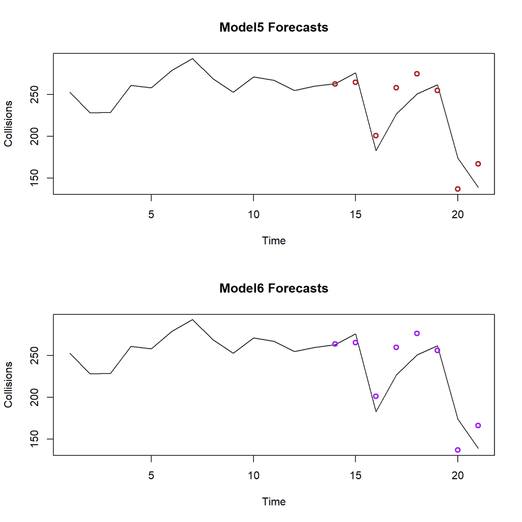

```r
l<-length(colls.ts)
pandemic.train<-colls.ts[1:(l-8)]
pandemic.test<-colls.ts[(l-7):l]
model5<-arima(pandemic.train,order=c(0,1,2),seasonal=list(orders=c(1,0,1),period=52),method="ML")
m5.resids<-resid(model5)
model6 = ugarchfit(spec4, m5.resids, solver = 'hybrid')

preds5<-predict(model5,n.ahead=4)

m5.resids.test<-pandemic.test[1:4]-preds5$pred

fore.series.6<-NULL

for(f in 1:4){
  ## Fit model
  data = m5.resids
  if(f>=2)
    data = c(m5.resids,m5.resids.test[1:(f-1)])

  fmod = ugarchfit(spec4, data, solver = 'hybrid')

  ## Forecast
  fore4 = ugarchforecast(fmod, n.ahead=1)
  fore.series.6 = c(fore.series.6, fore4@forecast$seriesFor)

}
preds5.orig<-preds5$pred
preds6.orig<-fore.series.6+preds5$pred
pandemic.train.4wk<-colls.ts[1:(l-4)]
pandemic.test.4wk<-colls.ts[(l-3):l]
model5.4wk<-arima(pandemic.train.4wk,order=c(0,1,2),seasonal=list(orders=c(1,0,1),period=52),method="ML")
m5.resids.4wk<-resid(model5.4wk)
model6.4wk = ugarchfit(spec4, m5.resids.4wk, solver = 'hybrid')
preds5.4wk<-predict(model5.4wk,n.ahead=4)

m5.resids.test.4wk<-pandemic.test[5:8]-preds5.4wk$pred

fore.series.6.4wk<-NULL

for(f in 1:4){
  ## Fit model
  data = m5.resids.4wk
  if(f>=2)
    data = c(m5.resids.4wk,m5.resids.test.4wk[1:(f-1)])

  fmod = ugarchfit(spec4, data, solver = 'hybrid')

  ## Forecast
  fore4 = ugarchforecast(fmod, n.ahead=1)
  fore.series.6.4wk = c(fore.series.6.4wk, fore4@forecast$seriesFor)

}
preds5.orig<-c(preds5.orig,preds5.4wk$pred)
preds6.orig<-c(preds6.orig,fore.series.6.4wk+preds5.4wk$pred)
par(mfrow=c(2,1))
ts.plot(colls.ts[(l-20):l],main="Model5 Forecasts",ylab="Collisions",
        ylim=c(min(preds5.orig),max(colls.ts[(l-20):l])))
points(ts(preds5.orig,start=14),lwd=2,col="brown")
ts.plot(colls.ts[(l-20):l],main="Model6 Forecasts",ylab="Collisions",
        ylim=c(min(preds6.orig),max(colls.ts[(l-20):l])))
points(ts(preds6.orig,start=14),lwd=2,col="purple")
```

```r
cat("Model5 MAPE:",mean(abs(preds5.orig-pandemic.test)/pandemic.test),
   "\nModel5 PM:", sum((preds5.orig-pandemic.test)^2)/sum((pandemic.test-mean(pandemic.test))^2),
"\nModel6 MAPE:",mean(abs(preds6.orig-pandemic.test)/pandemic.test),
"\nModel6 PM:", sum((preds6.orig-pandemic.test)^2)/sum((pandemic.test-mean(pandemic.test))^2))
```

```
## Model5 MAPE: 0.1017724
## Model5 PM: 0.2365107
## Model6 MAPE: 0.1023539
## Model6 PM: 0.2431401
```

Based on your observations, which methods would you recommend using to model the collision data? What are some ways that we might be able to further improve the fit and accuracy of models fit to the data? Compare your responses to this questions for the data before pandemic versus during pandemic.

*Response: Question 4*

Based on these observations, I would recommend using the methods explored in this analysis to predict the collision data. In order to further improve the fit and accuracy of these models, it might be helpful to include external factors which have been proven to affect driver behavior in the models; examples include traffic, weather, and vehicle type data.